# 第二章 R语言的本质 part1

Peng Shun

2020-04-03

R可以做的事情有很多，学习R最困难的部分之一就是找到自己的方向。同样，不同的人学习R语言也可能顺序不同。强烈建议初学者按照本书呈现的顺序深入阅读材料，因为后续的章节是建立在前几章知识的基础上的(**如果你在统计计算方面比较有经验，可以直接跳到相关部分**)。本章分为以下几节：

- 2.1 计算
- 2.2 逻辑运行
- 2.3 数列
- 2.4 测试与规定对象
- 2.5 缺失值，无穷大和不是数字的东西
- 2.6 向量与检索
- 2.7 向量化函数
- 2.8 矩阵与数组
- 2.9 抽样
- 2.10 循环与重复
- 2.11 列表
- 2.12 文本、字符串和模式匹配
- 2.13 时间与日期
- 2.14 环境
- 2.15 写R函数
- 2.16 读入数据

## 2.1计算

命令提示符**>**提示输入。在命令行中键入指令。可以在命令行中键入相关命令，将R作为计算器使用：

```r
log(42/7.3)
```

```
## [1] 1.749795
```

在R本身的编辑器中，每一行可以有最多8192个字符。如果你的指令一行都不能输入完，或你想在下一行显示你的代码。当你按下**回车键**时，在下一行就会出行提示符**+**，如下所示:

```r
5+6+3+6+4+2+4+8+
+ 3+2+7
```

```
## [1] 50
```

值得注意的是，**+**不会运算加法的功能。如果有输入错误，想要删除**+提示符**并返回到**>提示符**，那么按**Esc键**并使用***向上箭头**来重新编辑(不完整的)最后一行。

两个或两个以上的表达式只要用分号隔开就可以放在一行上，例如:

```r
2+3; 5*7; 3-7
```

```
## [1] 5
```

```
## [1] 35
```

```
## [1] -4
```

对于非常大的数字或非常小的数字，R的表示如下:

**1.2e3** 表示1200，e3表示“将小数点右移3位”;  
**1.2e-2** 表示0.012,e-2的意思是“小数点左移两位”;  
**3.9+4.5i** 是实数(3.9)和虚数(4.5)的复数，i是-1的平方根。

### 2.1.1R中的复数

复数由实数部分和虚数部分组成，虚数部分由小写字母i来标识，如下所示:

```r
z <- 3.5-8i
```

### 2.1.2舍入

在R中可以很容易地进行各种舍入(向上舍入、向下舍入、舍入到最接近的整数)。以数字5.7为例,求**“小于数字的最大整数”**的函数是**floor()**:

```r
floor(5.7)
```

```
## [1] 5
```

而取**“大于数字的最小整体”**的函数是**ceiling()**:

```r
ceiling(5.7)
```

```
## [1] 6
```

此外，还可以自己写一个四舍五入的函数，首先，将数字加上0.5，然后使用floor()函数。实际上，这是一个R本身的内置函数，但是可以地编写一个自己的函数来引入函数编写的概念。这个函数称为rounded():

```r
rounded <- function(x) floor(x+0.5)

#使用函数
rounded(5.7);rounded(5.4)
```

```
## [1] 6
```

```
## [1] 5
```

可以使用函数trunc()简单地去掉数字的小数部分:

```r
trunc(5.7);trunc(-5.7)
```

```
## [1] 5
```

```
## [1] -5
```

函数round()，可以通过在第二个参数来指定保留小数的位数:

```r
round(5.738888,2)
```

```
## [1] 5.74
```

小数位数与有效位数不一致。可以使用signif()函数控制数字中有效数字的位数。

```r
signif(12345678,4)
```

```
## [1] 12350000
```

### 2.1.3算数

R是一个功能齐全的计算器。可以用**+号**和**-号**进行加减运算，而除法是用**斜杠/**来完成的，乘法是用**星号***来完成。

```r
7 + 3 - 5 * 2
```

```
## [1] 0
```

平方使用**ˆ**:

```r
3^2/2
```

```
## [1] 4.5
```

所有你想要的数学函数都在这里(见表2.1)。log()函数以e为底(e = 2.718282)，反log函数为exp():

```r
log(10);exp(1)
```

```
## [1] 2.302585
```

```
## [1] 2.718282
```

表2.1:

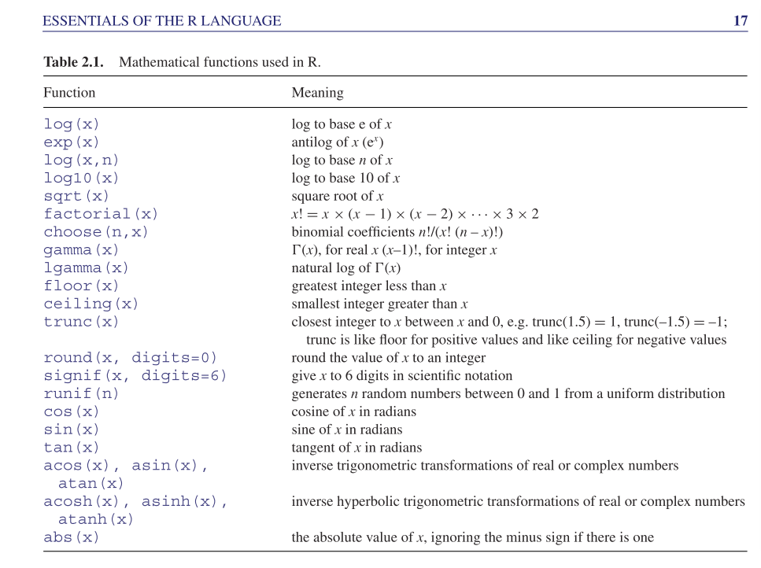

### 2.1.4除法和整除

整除和余数分别用%/%和%%来计算。

```r
#整除
119 %/% 13
```

```
## [1] 9
```

```r
#余数
119 %% 13
```

```
## [1] 2
```

### 2.1.5变量名和赋值

在R中为变量选择名称时，有三件重要的事情需要记住:

- R中的变量名是区分大小写的，所以y不等于Y。
- 变量名不应以数字(如1x)或运算符号(如%x)开头。
- 变量名不应包含空格。

在R中赋值的符号为**<-**。也可以用**=**,但是，有时可能会导致混淆，建议还是用前一个符号。例如：

```r
x <- 5
```

### 2.1.6运算符

表2.2:

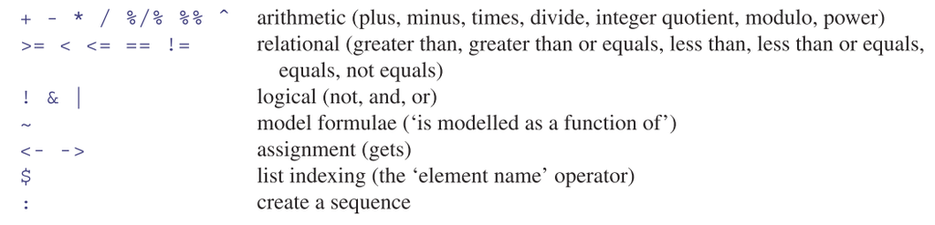

### 2.1.7整数

整数向量的存在是为了将数据传递给C或Fortran代码，这样小的整数数据就可以精确而紧凑地表示出来。不要试图使用整数函数来更改向量的类。这是一个数字向量，你想转换成一个整数向量:

```r
x <- c(5,3,7,8)

#是整数向量吗
is.integer(x)
```

```
## [1] FALSE
```

```r
#是数字向量吗
is.numeric(x)
```

```
## [1] TRUE
```

如果想将一个数字向量转换为整数向量，可以使用以下方法：

```r
x <- c(5,3,7,8)
x <- as.integer(x)
is.integer(x)
```

```
## [1] TRUE
```

还可以起到直接取整的功能：

```r
as.integer(5.7)
```

```
## [1] 5
```

```r
as.integer(-5.7)
```

```
## [1] -5
```

```r
as.integer(5.7 -3i)
```

```
## [1] 5
```

### 2.1.8因子

因子是具有固定数量的层次的分类变量。最简单例子可能是“性别”的变量，它有两个类别。如果你有三个女性和两个男性，你可以创造这样的因子:

```r
gender <- factor(c("female", "male", "female", "male", "female"))
class(gender)
```

```
## [1] "factor"
```

```r
mode(gender)
```

```
## [1] "numeric"
```

通常，通过使用read.table从文件中读取数据，您将创建一个dataframe。当你这样做时，所有包含一个或多个字符串的变量都将自动转换为因子。

```r
data <- read.table("D:/future_plan/group_learning/Dataset/daphnia.txt",header=T)
attach(data)
head(data)
```

```
##   Growth.rate Water Detergent Daphnia
## 1    2.919086  Tyne    BrandA  Clone1
## 2    2.492904  Tyne    BrandA  Clone1
## 3    3.021804  Tyne    BrandA  Clone1
## 4    2.350874  Tyne    BrandA  Clone2
## 5    3.148174  Tyne    BrandA  Clone2
## 6    4.423853  Tyne    BrandA  Clone2
```

这个数据框中包含一个连续的因变量(Growth.rate)和三个分类预测变量(Water, and Daphnia)，所有这些都是因子。在统计建模中，因子与方差分析(所有预测变量均为分类变量)和协方差分析(部分预测变量为分类变量，部分预测变量为连续变量)相关。

以下是有关因子的一些重要函数。如果想要检查一个变量是否是一个因子:

```r
is.factor(Water)
```

```
## [1] TRUE
```

为了发现因子层次的名称，可以使用level()函数:

```r
levels(Detergent)
```

```
## [1] "BrandA" "BrandB" "BrandC" "BrandD"
```

为了发现变量的类别数，使用nlevels函数:

```r
nlevels(Detergent)
```

```
## [1] 4
```

```r
#等同于
length(levels(Detergent))
```

```
## [1] 4
```

默认情况下，R会按字母顺序处理因子级别。如果你想改变:

```r
gender <- factor(gender,levels = c(1,2),labels = c("male","female"))
```

*只有==和!=可以用于因子*。还要注意，一个因子只能与另一个具有相同水平的因子(不一定具有相同的顺序)或字符向量进行比较。

## 2.2逻辑操作

计算的一个关键部分涉及到对事物的提问。一个比另一个大吗?两个东西大小一样吗?问题可以用and或not这样的词连接在一起。在R中的问题通常评估为真或假，但有一个可能的选项(当答案不可用时，NA)。**在R 中<表示小于，>表示大于,!意味着不**(见表2.3)。

表2.3:

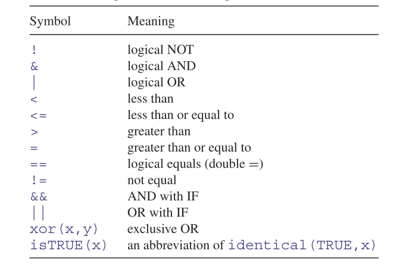

### 2.2.1TRUE和FALSE

可以用T表示TRUE，用F表示FALSE。因此，很明显有(应该注意，T和F可能被分配给变量作名称)：

```r
#TRUE等于FALSE吗
TRUE == FALSE
```

```
## [1] FALSE
```

```r
T == F
```

```
## [1] FALSE
```

还有不那明显的：

```r
T <- 0
T == FALSE
```

```
## [1] TRUE
```

```r
F <- 1
TRUE == F
```

```
## [1] TRUE
```

### 2.2.2与实数是否相等的检验

```r
x <- sqrt(2)
x * x == 2
```

```
## [1] FALSE
```

这是由于计算机的浮点运算有一定的范围，超出这一范围就会使用四舍五入的方式进行估计。因此，导致这两个数不相等。

### 2.2.3浮点数是否相等可使用all.equal

```r
x <- 0.3 - 0.2
y <- 0.1
x == y
```

```
## [1] FALSE
```

```r
identical(x,y)
```

```
## [1] FALSE
```

```r
all.equal(x,y)
```

```
## [1] TRUE
```

### 2.2.4使用all.equal汇总对象之间的差异

all.equal是一个非常有用的函数，用来检查对象是否如期望的那样。

```r
a <- c("cat","dog","goldfish")
b <- factor(a)

all.equal(a,b)
```

```
## [1] "Modes: character, numeric"
## [2] "Attributes: < target is NULL, current is list >"
## [3] "target is character, current is factor"
```

```r
#mode：表示对象在内存中的存储类型
mode(b)
```

```
## [1] "numeric"
```

```r
#class：是一种抽象类型，或者理解为一种数据结构（数据框，因子，列表）
class(b)
```

```
## [1] "factor"
```

```r
attributes(b)
```

```
## $levels
## [1] "cat"      "dog"      "goldfish"
##
## $class
## [1] "factor"
```

### 2.2.5TRUE与FALSE的组合评价

重要的是要理解逻辑变量的组合是如何计算的，并理解逻辑操作(如表2.2中的操作)在有缺失值NA时是如何工作的。

```r
x <- c(NA, FALSE, TRUE)
names(x) <- as.character(x)

outer(x, x, "&")
```

```
##        <NA> FALSE  TRUE
## <NA>     NA FALSE    NA
## FALSE FALSE FALSE FALSE
## TRUE     NA FALSE  TRUE
```

```r
outer(x, x, "|")
```

```
##       <NA> FALSE TRUE
## <NA>    NA    NA TRUE
## FALSE   NA FALSE TRUE
## TRUE  TRUE  TRUE TRUE
```

### 2.2.6逻辑运算

涉及逻辑表达式的算术在编程和变量选择中非常有用。需要理解的关键是，逻辑表达式true或false,可以转换为数值:1表示true, 0表示false。假设x是这样一个从0到6的序列：

```r
x <- 0:6

#x小于4的有哪些
x < 4
```

```
## [1]  TRUE  TRUE  TRUE  TRUE FALSE FALSE FALSE
```

```r
#所有的x都大于0吗
all(x>0)
```

```
## [1] FALSE
```

```r
#有任何x小于0吗
any(x<0)
```

```
## [1] FALSE
```

此外，根据逻辑运算的结果，我们可以用sum来计算(x<4)的元素的个数:

```r
sum(x<4)
```

```
## [1] 4
```

```r
#还可以将结果返回运算，乘以7个[0,1]上的均匀分布随机数
(x < 4)*runif(7)
```

```
## [1] 0.2100561 0.7025645 0.6792846 0.5985758 0.0000000 0.0000000 0.0000000
```

## 2.3生成序列

创建向量的一个重要方法是生成一个数列。最简单的数列的间隔为1，你所要做的就是指定第一个和最后一个值并由冒号分隔。

```r
0:10
```

```
##  [1]  0  1  2  3  4  5  6  7  8  9 10
```

```r
15:5
```

```
##  [1] 15 14 13 12 11 10  9  8  7  6  5
```

还能使用seq函数，其有三个参数分别为：from,to,by，即从哪个数开始，到哪个数结束，间隔为多少。

```r
seq(0, 1.5, 0.1)
```

```
##  [1] 0.0 0.1 0.2 0.3 0.4 0.5 0.6 0.7 0.8 0.9 1.0 1.1 1.2 1.3 1.4 1.5
```

有时需要基于已有数据生成数列，如：

```r
N <- c(55,76,92,103,84,88,121,91,65,77,99)

seq(from=0.04,by=0.01,length=length(N))
```

```
##  [1] 0.04 0.05 0.06 0.07 0.08 0.09 0.10 0.11 0.12 0.13 0.14
```

```r
seq(0.04,by=0.01,along=N)
```

```
##  [1] 0.04 0.05 0.06 0.07 0.08 0.09 0.10 0.11 0.12 0.13 0.14
```

```r
seq(from=0.04,to=0.14,along=N)
```

```
##  [1] 0.04 0.05 0.06 0.07 0.08 0.09 0.10 0.11 0.12 0.13 0.14
```

```r
sequence(c(4,3,4,4,4,5))
```

```
##  [1] 1 2 3 4 1 2 3 1 2 3 4 1 2 3 4 1 2 3 4 1 2 3 4 5
```

### 2.3.1生成重复

生成重复的数字或字符的函数是rep。

```r
#9重复5次
rep(9,5)
```

```
## [1] 9 9 9 9 9
```

```r
#重复数列2次
rep(1:4, 2)
```

```
## [1] 1 2 3 4 1 2 3 4
```

```r
#将数列中的元素每个重复2次
rep(1:4, each = 2)
```

```
## [1] 1 1 2 2 3 3 4 4
```

```r
#将数列中的元素每个重复2次，再将这一结果重复3次
rep(1:4, each = 2, times = 3)
```

```
##  [1] 1 1 2 2 3 3 4 4 1 1 2 2 3 3 4 4 1 1 2 2 3 3 4 4
```

```r
rep(1:4,1:4)
```

```
##  [1] 1 2 2 3 3 3 4 4 4 4
```

```r
rep(1:4,c(4,1,4,2))
```

```
##  [1] 1 1 1 1 2 3 3 3 3 4 4
```

### 2.3.2生成因子水平

```r
gl(4,3)
```

```
##  [1] 1 1 1 2 2 2 3 3 3 4 4 4
## Levels: 1 2 3 4
```

```r
gl(4,3,24)
```

```
##  [1] 1 1 1 2 2 2 3 3 3 4 4 4 1 1 1 2 2 2 3 3 3 4 4 4
## Levels: 1 2 3 4
```

```r
Temp <- gl(2, 2, 24, labels = c("Low", "High"))
Soft <- gl(3, 8, 24, labels = c("Hard","Medium","Soft"))
M.user <- gl(2, 4, 24, labels = c("N", "Y"))
Brand <- gl(2, 1, 24, labels = c("X", "M"))
data.frame(Temp,Soft,M.user,Brand)
```

```
##    Temp   Soft M.user Brand
## 1   Low   Hard      N     X
## 2   Low   Hard      N     M
## 3  High   Hard      N     X
## 4  High   Hard      N     M
## 5   Low   Hard      Y     X
## 6   Low   Hard      Y     M
## 7  High   Hard      Y     X
## 8  High   Hard      Y     M
## 9   Low Medium      N     X
## 10  Low Medium      N     M
## 11 High Medium      N     X
## 12 High Medium      N     M
## 13  Low Medium      Y     X
## 14  Low Medium      Y     M
## 15 High Medium      Y     X
## 16 High Medium      Y     M
## 17  Low   Soft      N     X
## 18  Low   Soft      N     M
## 19 High   Soft      N     X
## 20 High   Soft      N     M
## 21  Low   Soft      Y     X
## 22  Low   Soft      Y     M
## 23 High   Soft      Y     X
## 24 High   Soft      Y     M
```

## 2.4测试与规定对象

表2.4:

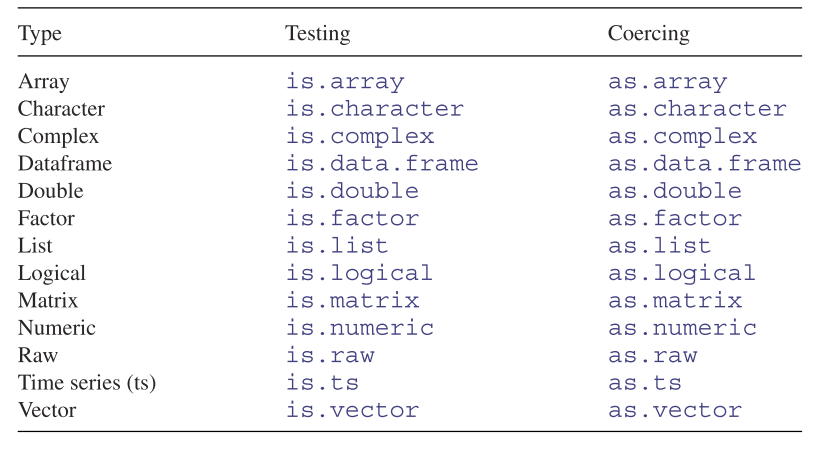

## 2.5缺失值，无穷大和不是数字的东西

在R中用Inf表示正无穷，用-Inf表示负无穷。

```r
3/0; -12/0
```

```
## [1] Inf
```

```
## [1] -Inf
```

无穷也可以用于计算之中，如：

```r
(0:3)^Inf
```

```
## [1]   0   1 Inf Inf
```

然而，其他的计算得出的不是数字,由NaN(“不是数字”)表示。

```r
Inf-Inf
```

```
## [1] NaN
```

```r
Inf/Inf
```

```
## [1] NaN
```

### 2.5.1缺失值

缺失值是我们处理数据时必须要面对的一种数据形式。它们影响了模型拟合函数的操作和建模的过程。

```r
y <- c(4,NA,7)

y[! is.na(y)]
```

```
## [1] 4 7
```

```r
mean(y)
```

```
## [1] NA
```

```r
mean(y,na.rm=T)
```

[output not shown]